# Homework 3

### Question 12

Assume that $z = \beta_0 + \beta_{1}x_{1}$ and $p = logistic(z)$. How do the odds of the outcome change if you increase $x_{1}$ by two? Demonstrate this.

Doubling the x of the odds ratio reach the limit faster. For example, set $beta_1=3$ and $beta_0=1$.Then x follows the 1 and 2 multipliers below as shown, respectively. The limits both go to -1 as x approaches $\infty$.

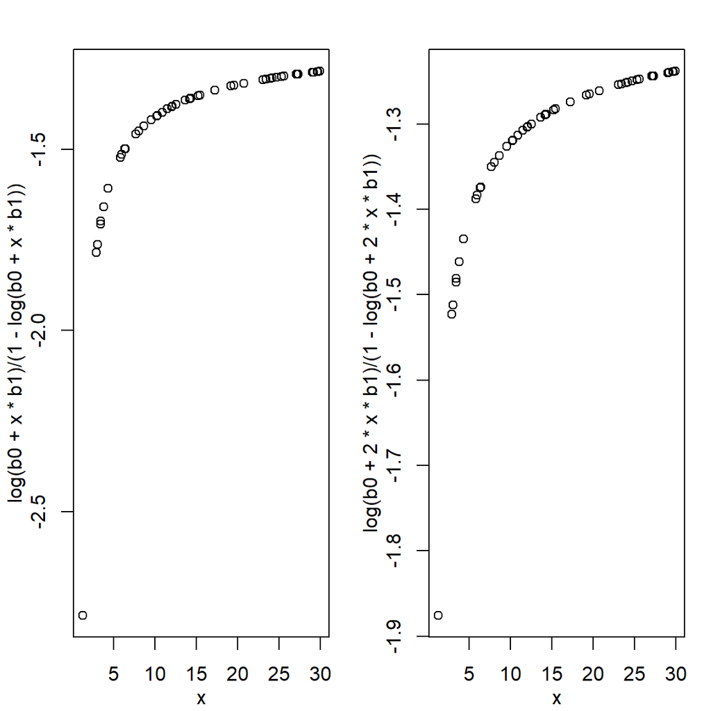

```r
set.seed(7)
b0=1
b1=3
x=runif(50,min=1,max=30)
par(mfrow=c(1,2), mgp=c(2,1,0), mar=c(3,3,2,1)+.1)
plot(x, log(b0+x*b1)/(1-log(b0+x*b1)))
plot(x, log(b0+2*x*b1)/(1-log(b0+2*x*b1)))
```

Assume now that $\beta_1$ is negative. What value does $p$ approach as $x_{1}$ approaches $\infty$? What value does $p$ approach as $x_{1}$ approaches $-\infty$?

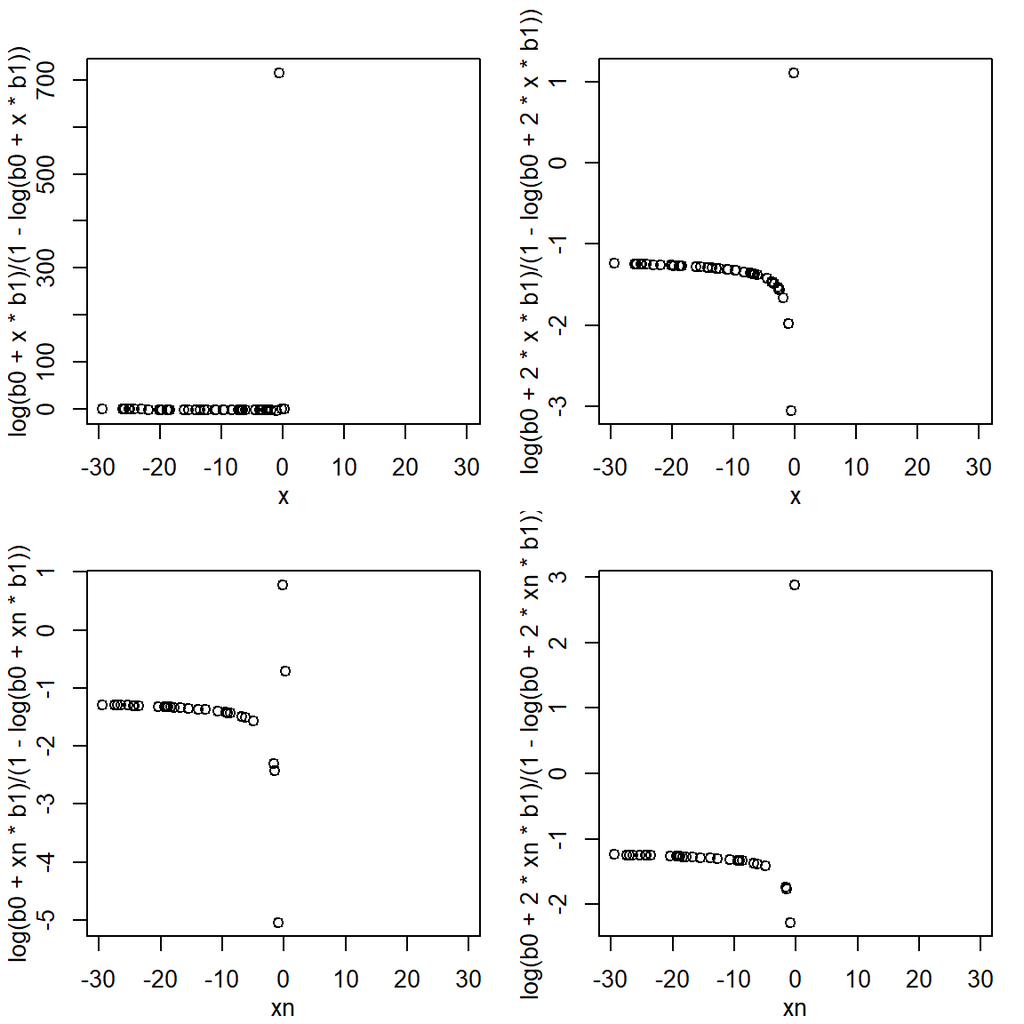

```r
set.seed(7)
b0=1
b1=-3
x=runif(80,min=-30,max=30)
xn=runif(80,min=-30,max=30)
par(mfrow=c(2,2), mgp=c(2,1,0), mar=c(3,3,2,1)+.1)
plot(x, log(b0+x*b1)/(1-log(b0+x*b1)))
plot(x, log(b0+2*x*b1)/(1-log(b0+2*x*b1)))
plot(xn, log(b0+xn*b1)/(1-log(b0+xn*b1)))
plot(xn, log(b0+2*xn*b1)/(1-log(b0+2*xn*b1)))
```